# Worksheets 5-8

Manuel Rosero

10/27/2016

# Worksheet 5 - Do chapter 3 of online R tutorial http://tryr.codeschool.com/

1. How could you make a matrix that is 5 columns wide and 2 rows deep and that has the value 1 in each cell?
- `Matrix(1,2,5)`
2. How could you make a matrix that is 2 wide and 2 deep and that has the values 10, 14, 20 and 30 in it?

```r
a<-c(10,14,20,30)
matrix(a,2,2)
```

```
##      [,1] [,2]
## [1,]   10   20
## [2,]   14   30
```

3. What does the dim assignment function do to a vector?
- Dim rearranges a linear vector in the dimensions you specify. Therefore, making that linear vector into a matrix with the specified dimensions.
4. This chapter is about matrices. Can you think of data that would come in the form of a matrix? Remember that in a matrix, all cells have the same datatype.
- As we learned in the previous part of the course, any genetic data collected on the expression of genes can be expressed in a matrix form.
5. You learned three commands to plot a matrix. Which are they? Which one do you think would be most useful?
- We learned about contour, persp, and image. I believe that for the purpose of bioinformatics analysis image can be a more useful tool because we could create a heat map and visually identify genes that are expressed differently. So that those with higher expression levels would show a certain color and those with lower expression would show a less intense version of that same color.

**Finished!**

Name: Manuel Rosero

Date: 10/27/16

# Worksheet 6: Do chapter 4 of Try R codeschool

You can do all the exercises in the online tutorial first, then come back to this worksheet to answer a few questions.

```
#to create a horizontal line at 10
abline(h=10)
#to create a vertical line at 10
abline(v=10)
```

If you want to try this out (which would be great! use Rstudio), you need to first create a plot with some data, for example:

```
x <- 1:12
y <- 1:12
plot(x,y)
```

Now you can play with the `abline()` function to add horizontal and vertical lines.

**Awesome! Another tutorial done!**

Name: Manuel Rosero

Date: 10/27/16

**Install R and RStudio prior to working on this worksheet**  
#Worksheet 7 Getting to know Rstudio through videos from Udacity.

If you are doing this at home, you should first install RStudio. If you are in the computer room, you can start with this worksheet. Rstudio is installed on the computers, find it in the “dock” and start the program.

**Task 1.** Watch video on Rstudio basics:

https://www.youtube.com/watch?&v=FDSmlIBy7ko

**Task 2.** Watch video on changing the settings of Rstudio (up to 45 seconds).

https://www.youtube.com/watch?&v=vLlj5nNj8x4

**Task 3.** Change the settings for “appearance” and enjoy the new colors.

**Task 4.** Watch video on getting help for R

https://www.youtube.com/watch?v=ABVX527RODE

**Task 5.** Go to the quick R website (google quick R or go to http://www.statmethods.net/). Search for information on bar plots. You’ll need it for the next task.

**Task 6.** Create a new R script in Rstudio

Write code to make two numeric vectors of equal length, and plot them in a scatter plot. Then plot one of them in a barplot. Make the barplot horizontal. Create a matrix that combines both vectors using rbind(vector1,vector2) and create a barplot of that matrix. Save your code in a place on your computer where you can find it back.

How to save your code in an R script: https://vimeo.com/142568715

Append/copy your .R code here as a code block i.e. enclosed in 3 backticks, e.g.:

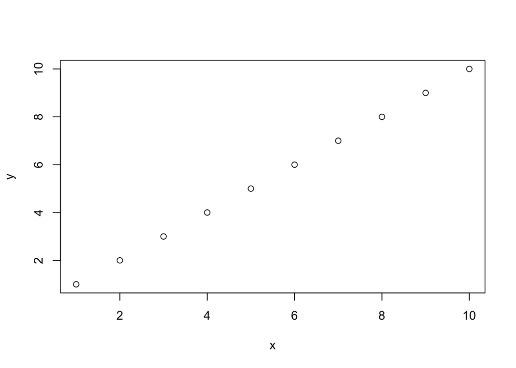

```r
x<-c(1:10)
y<-c(1:10)
plot(x,y)
```

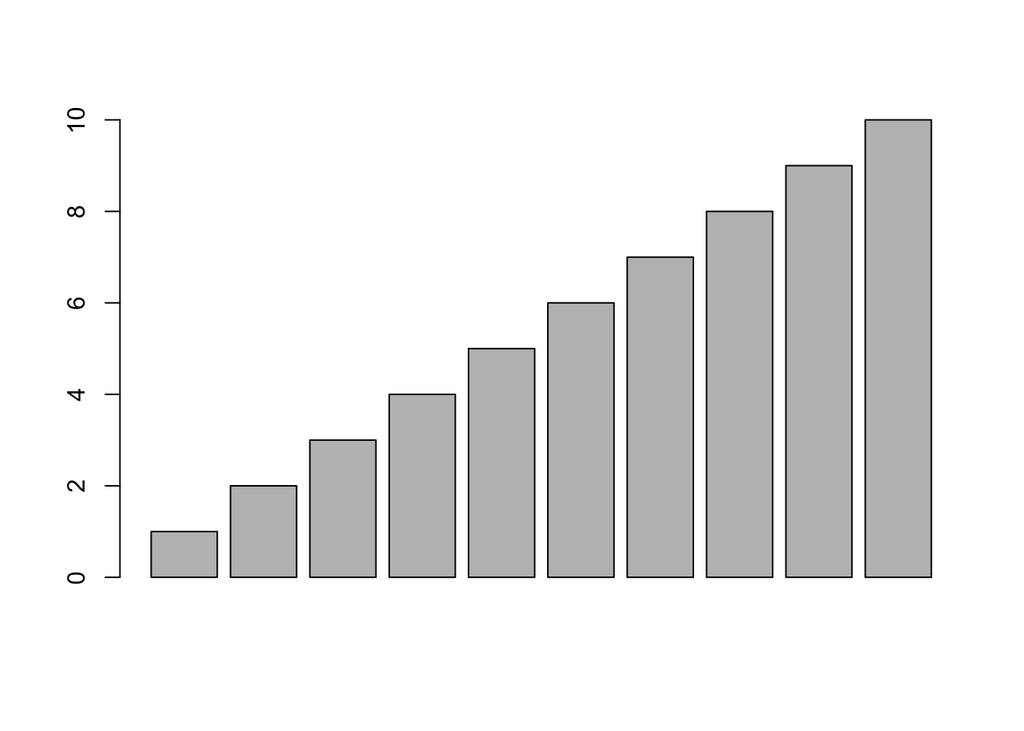

```r
barplot(x)
```

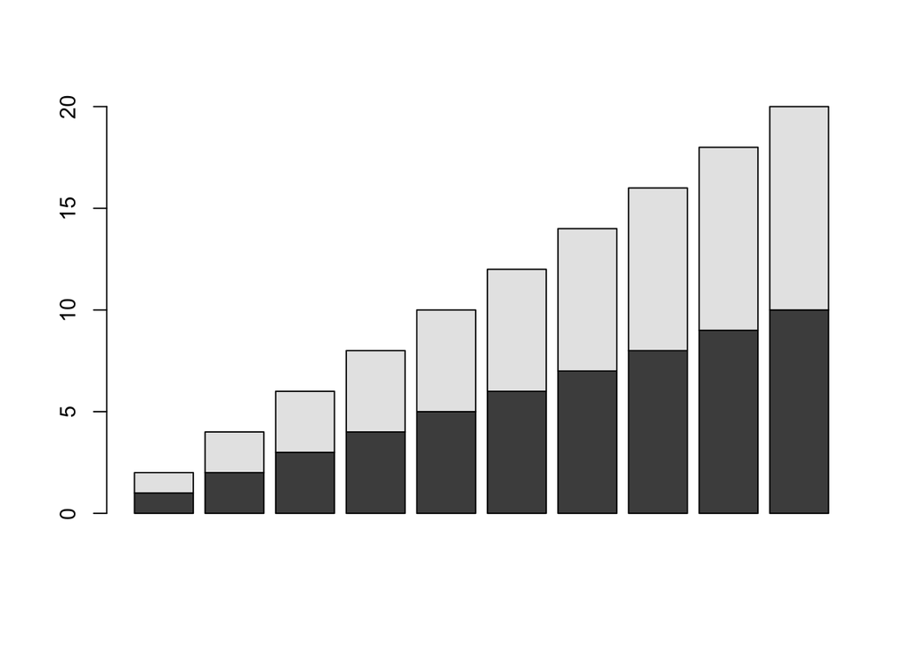

```r
matrix<-rbind(x,y)
barplot(matrix)
```

**Doing great!**

Name: Manuel Rosero

Date: 10/27/16

# Worksheet 8: Chapter 5 of Try R codeschool

Chapter 5 is about factors. Nominal data should be stored as factors. The following are examples of data that should be stored as factors:

1. Gender (male / female / unspecified)
2. Nationality (e.g., US, Canada, Mexico)
3. Type of animal (e.g., dog, fish, cat, horse)
4. Age if range is used (below 40, 40 or older)

The following are examples of data that should not be stored as factors:

1. Age if years or months are used (numeric)
2. Height (numeric)
3. Price (numeric)

**Task 1.** Come up with at least 4 examples of data that should be stored as factors.

- Perhaps in an experiment whee each subject receives a different treatment, the list of treatment names should be stored as a factor. that way, it would be easy to determmine the different treatments (factor’s levels) as well as how many subjects recieved that treatment.

**Task 2.** Explain all parts of the command `plot(weights, prices, pch=as.integer(types))`

**On your way to becoming an R ninja!**

Name:Manuel Rosero

Date: 10/27/16